[CM3070] Final Project - BSc CS University of London

Deep Learning on Satellite Imagery

by Arjun Bajaj

# Analysing Pico Inference Results and Evaluating the Model

At this point, the model has been successfully deployed to the Pico.

The Pico requires the images in a certain format (a `float32` array of `4` dimensions). This set of images is built automatically when the `scripts/init_datasets.sh` script is run.

The host script `scripts/infer_on_pico.py` sends `1,000` processed images to the Pico, and collects the inference results in a CSV.

This notebook analyses the results of the CSV by calculating the accuracy, and rendering the confusion matrix and classification report. The final Keras model is also evaluated below for comparison purposes.

```python
import os
from core import load_eurosat

import numpy as np
import pandas as pd

import tensorflow as tf
from tensorflow import keras

import seaborn as sns
import sklearn.metrics as metrics
```

```python
(_, _, test) = load_eurosat()
```

```
Found 21600 files belonging to 10 classes.
Found 2700 files belonging to 10 classes.
Found 2700 files belonging to 10 classes.
```

## EuroSAT Classes

The classification report and confusion matrix require the list of classes in the EuroSAT dataset. It is fetched from the directly listing here.

```python
classes = np.sort([
  cl for cl in os.listdir('../datasets/eurosat/test') if cl not in ['.DS_Store', '..']
])

classes
```

```
array(['AnnualCrop', 'Forest', 'HerbaceousVegetation', 'Highway',
       'Industrial', 'Pasture', 'PermanentCrop', 'Residential', 'River',
       'SeaLake'], dtype='<U20')
```

## Helper Functions

The functions to render the confusion matrix, line plot, and classification report are defined below.

```python
def configure_fig_size():
  # Configure the Seaborn figure size.
  sns.set(rc={
    "figure.figsize":(15, 10), "font.size":20,
    "axes.titlesize":40, "axes.labelsize":20,
    "xtick.labelsize":20, "ytick.labelsize":20
  })

def confusion_matrix(true, pred):
  configure_fig_size()
  sns.heatmap(
    metrics.confusion_matrix(true, pred),
    annot=True,
    xticklabels=classes, yticklabels=classes,
    cmap='Blues', fmt='d'
  ).set(title='Confusion Matrix')

def line_plot(true, pred):
  configure_fig_size()
  (
    sns
    .lineplot(x = true, y = pred, palette = 'Blues', linewidth=2.5, legend=False)
    .set(title='True vs. Predicted', xlabel='True', ylabel='Predicted')
  )

def classification_report(true, pred):
  print(metrics.classification_report(
    true, pred, target_names=classes, zero_division=0
  ))
```

# Running Inference on the Pico

To run inference on the Pico, first deploy the UF2 image located at `artifacts/diode.uf2` to a Pico. To do this, hold the `BOOTSEL` button on the Pico and connect it to the computer. Then drag and drop the UF2 file to the newly mounted drive (named `RPI-RP2`). After that, disconnect the Pico, and then run the script. The script tells you to connect the Pico when it starts. The inference automatically starts after the Pico is detected by the script.

Note: Ensure that the script is run in the Conda environment that's already setup. Follow instructions in `readme.md` to setup the Conda environment.

The following is the trimmed output of when the script was exectued to collect the results presented in this notebook:

```
(base) ~/eurosat/scripts $ python3 infer_on_pico.py
Please connect your Pico to the computer now.
Pico is connected at: /dev/tty.usbmodem1101
Preparing to run Inference on Pico
Pico is ready to run inference
Sending images...
Found 1000 images in ../datasets/pico-test-images, using 1000.
1 - 0000_1.bin      True: 1 Pred: 1 Time: 1065
2 - 0001_5.bin      True: 5 Pred: 5 Time: 1064
3 - 0002_3.bin      True: 3 Pred: 3 Time: 1064
4 - 0003_7.bin      True: 7 Pred: 7 Time: 1064
5 - 0004_8.bin      True: 8 Pred: 8 Time: 1064
      ...output trimmed for brevity...
996 - 0995_1.bin    True: 1 Pred: 1 Time: 1065
997 - 0996_0.bin    True: 0 Pred: 0 Time: 1064
998 - 0997_5.bin    True: 5 Pred: 5 Time: 1064
999 - 0998_4.bin    True: 4 Pred: 4 Time: 1065
1000 - 0999_2.bin   True: 2 Pred: 2 Time: 1064
Inference on Pico completed in 2205 seconds
Results are saved to ../artifacts/pico-inference-results.csv
You can safely disconnect the Pico from the computer now.
```

# Evaluating The Pico Inference Results

The inference results were collected in a CSV as the Pico predicted each image. This section presents and visualizes the results.

```python
results = pd.read_csv('../artifacts/pico-inference-results.csv')
results
```

|  | path | true | pred | time |
| --- | --- | --- | --- | --- |
| 0 | 0000_1.bin | 1 | 1 | 1065 |
| 1 | 0001_5.bin | 5 | 5 | 1064 |
| 2 | 0002_3.bin | 3 | 3 | 1064 |
| 3 | 0003_7.bin | 7 | 7 | 1064 |
| 4 | 0004_8.bin | 8 | 8 | 1064 |
| ... | ... | ... | ... | ... |
| 995 | 0995_1.bin | 1 | 1 | 1065 |
| 996 | 0996_0.bin | 0 | 0 | 1064 |
| 997 | 0997_5.bin | 5 | 5 | 1064 |
| 998 | 0998_4.bin | 4 | 4 | 1065 |
| 999 | 0999_2.bin | 2 | 2 | 1064 |

1000 rows × 4 columns

```python
# Extract the true and predicted data into numpy arrays
true = results['true'].to_numpy()
pred = results['pred'].to_numpy()
```

### Accuracy of images inferred on the Pico

```python
print(f'Accuracy of Inference on Pico of Test Images: {metrics.accuracy_score(true, pred):.2%}')
```

```
Accuracy of Inference on Pico of Test Images: 93.00%
```

### Average time to infer one image

```python
print(f"Average Time for Inference of One Image: {results['time'].mean() / 1000 :.2f} seconds")
```

```
Average Time for Inference of One Image: 1.06 seconds
```

### Classification Report

```python
classification_report(true, pred)
```

```
                      precision    recall  f1-score   support

          AnnualCrop       0.96      0.87      0.92       119
              Forest       0.96      0.99      0.97       116
HerbaceousVegetation       0.88      0.89      0.88       116
             Highway       0.91      0.92      0.92        90
          Industrial       0.97      0.93      0.95        89
             Pasture       0.94      0.87      0.90        68
       PermanentCrop       0.85      0.85      0.85        94
         Residential       0.94      0.99      0.97       113
               River       0.88      0.95      0.92        80
             SeaLake       0.99      1.00      1.00       115

            accuracy                           0.93      1000
           macro avg       0.93      0.93      0.93      1000
        weighted avg       0.93      0.93      0.93      1000
```

### Confusion Matrix

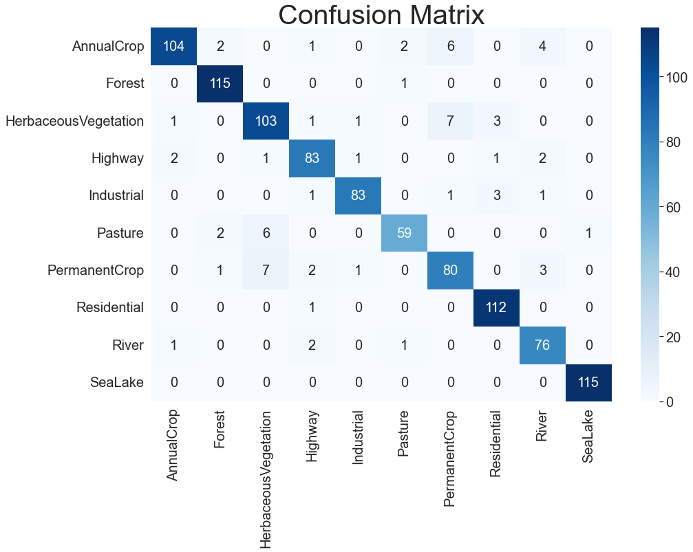

```python
confusion_matrix(true, pred)
```

### Line Plot

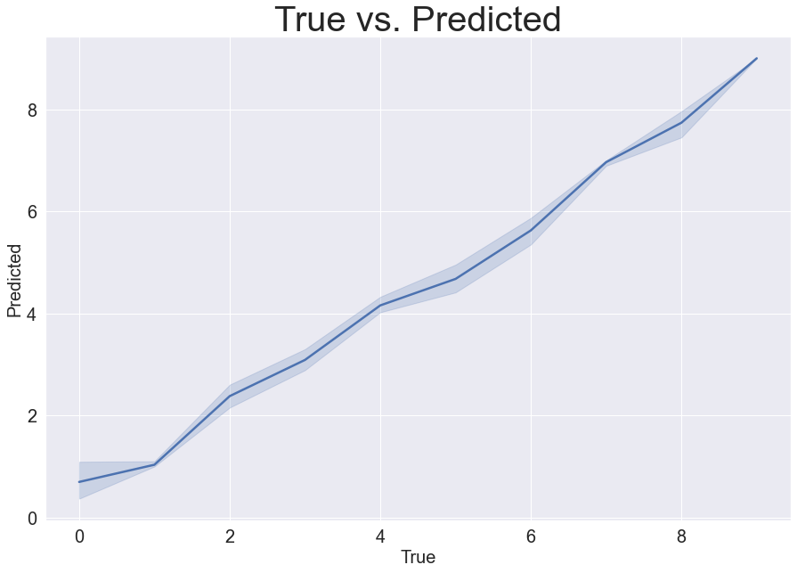

```python
line_plot(true, pred)
```

The linearity of the line plot above shows that most images are correctly predicted.

# Evaluating the Final Model on the Test Dataset

The final model is also evaluated on the entire test dataset of `2,700` images, instead of the `1,000` used for Pico.

### Accuracy

```python
# Load Final Model
test_model = keras.models.load_model('../artifacts/eurosat.keras')

# Evaluate using the test dataset
[loss, accuracy] = test_model.evaluate(test)

print(f"Accuracy on Test Dataset: {accuracy*100:.2f}%")
```

```
Accuracy on Test Dataset: 91.78%
```

### Classification Report

```python
# Predict the dataset to render a classification report
test_preds = test_model.predict(test)
test_preds = np.argmax(test_preds, axis=1)

test_labels = np.array(list(
  test.unbatch().map(lambda _, y: y).as_numpy_iterator()
), dtype=np.uint8)

classification_report(test_labels, test_preds)
```

```
                      precision    recall  f1-score   support

          AnnualCrop       0.94      0.87      0.90       300
              Forest       0.96      0.98      0.97       300
HerbaceousVegetation       0.88      0.88      0.88       300
             Highway       0.89      0.90      0.90       250
          Industrial       0.94      0.90      0.92       250
             Pasture       0.92      0.89      0.90       200
       PermanentCrop       0.83      0.88      0.85       250
         Residential       0.93      0.99      0.95       300
               River       0.89      0.88      0.88       250
             SeaLake       1.00      0.99      0.99       300

            accuracy                           0.92      2700
           macro avg       0.92      0.91      0.92      2700
        weighted avg       0.92      0.92      0.92      2700
```

### Confusion Matrix

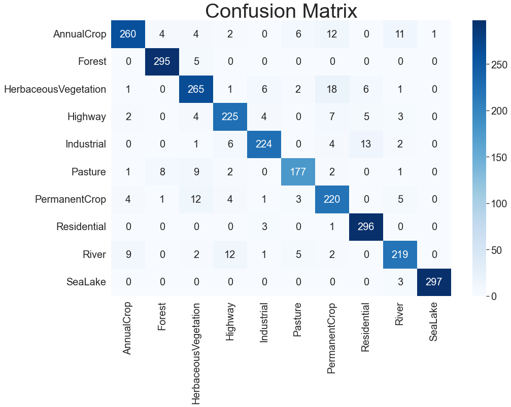

```python
confusion_matrix(test_labels, test_preds)
```

### Line Plot

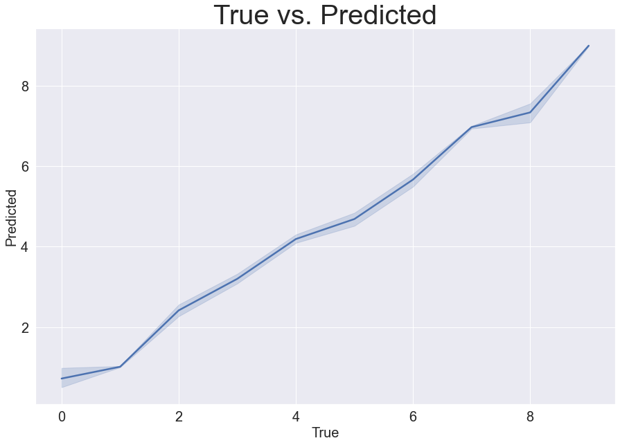

```python
line_plot(test_labels, test_preds)
```

# Results

The inference results of the Pico show a slightly higher accuracy of `93%` compared to `91.78%`. This could be due to the random selection of the subset of `1,000` images from the entire `2,700` image dataset.

It is important to note that the Universal Workflow of Deep Learning described in the *Deep Learning with Python* book prescribes re-training the final model with the training and validation dataset combined for the number of epochs that leads to the best accuracy. Since the validation dataset is only `10%` of the data, and retraining the models takes a long time, this process is not done here. The model is very effective even without doing this process.

Overall, the `93%` accuracy reached by the Pico demonstrates that Deep Learning and specifically Image Classification on a microcontroller is suitable and performant.